# Trabalho final - Análise de dados 2021/1

Liliane Gobetti Fagundes

```r
chooseCRANmirror(graphics=FALSE, ind=1)
knitr::opts_chunk$set(echo = TRUE)
```

IMPACTO DA RENDA NOS RESULTADOS ELEITORAIS

1. INTRODUÇÃO

Nos últimos anos há inúmeros trabalhos que apresentam o debate sobre a questão de gênero nos espaços de poder. Primordialmente, a falta de representação feminina nos espaços políticos e o quanto isso reflete em políticas públicas nas mais diversas áreas, principalmente em questões relacionadas diretamente com a saúde feminina e a direitos reprodutivos, e até mesmo com as implicações para a própria democracia.  
Do ponto de vista sociológico, diversas autoras abordam o que é considerado o “papel da mulher”. Carole Pateman em seu livro chamado “O Contrato sexual” explana sobre a dicotomia entre privado e público, sobre como a mulher esta “naturalmente” voltada para uma vida privada, onde caberia a ela as atividades ditas reprodutivas (por exemplo, casa, atividades domésticas, maternidade), enquanto o homem estaria voltado para a vida pública, para atividades ditas produtivas (comércio, indústria, entre outros). Essa diferenciação e divisão tão arraigada socialmente e culturalmente nas sociedades, especialmente na brasileira, repercutem fortemente nos cargos e funções ocupados pelas mulheres. Essa dicotomia tão naturalizada e normalizada influencia na forma que pensamos sobre gênero, política e representação. Nesse cenário de pouca representatividade, a violência contra candidatas mulheres é a cada eleição maior. Algumas são alvos das mais absurdas histórias no intituito de descredibilizá-las e, quase sempre, são violências pautadas no gênero e na sexualidade. A literatura política, aponta diversos fatores como motivos para a baixa representação de mulheres em cargos políticos.Um dos principais, pontuado por Speck e Sacchet (2012a) é de que o financiamento de campanha das mulheres é significativamente menor que o dos homens, e dada à importância que financiamento tem para o sucesso eleitoral, e a correlação entre arrecadação de campanha e número de eleitos, esse pode ser um dos motivos de termos menos mulheres eleitas, visto que as mulheres arrecadam menos dinheiro para as campanhas e recebem menos da distribuição feita pelos partidos. Speck e Mancuso (2014) também pontuam essa associação e correlação positiva e estatisticamente significativa entre recursos e votos para as eleições. Sacchet e Speck (2012b) argumentam que as mulheres têm menos recursos próprios para investir na fase inicial das campanhas, sendo essa desigualdade progressiva ao longo da vida dessas candidatas dado que os homens recebem mais incentivo financeiro da iniciativa privada (quando ainda era permitido) e dos partidos. A partir disso, a questão de pesquisa central do trabalho é observar se a renda declarada pelas candidatas influencia em seus resultados eleitorais. Cabe ressaltar que para além da renda há outras variáveis essenciais para a compreensão do fenômeno da baixa eleição de mulheres e também sobre quem são essas mulheres eleitas. Para isso, podemos sinalar o conceito de capital social e de capital político trabalhado por Bourdieu que, em uma interpretação bem trivial, seria uma certificação quase que “nata” de que alguns indivíduos tenham maior acesso ao campo político e de estruturas de oportunidade políticas favoráveis, seja através do capital social, de contatos, de família, entre outros. Sacchet e Speck (2012b) pontuam que

“Tanto o capital político como o social do tipo público estão positivamente correlacionados ao financiamento eleitoral. Candidatos com mais acesso a estes recursos terão maior facilidade para arrecadar fundos de campanha. Em termos gerais, as mulheres carecem tanto de capitais políticos e social do tipo público, quanto de recursos financeiros pessoais, fazendo com que elas entrem no processo político em desigualdade de condições com os homens.” (SACCHET; SPECK, 2012b, p. 419).

Outro ponto sinalizado por Sacchet é o de que as mulheres são mais prejudicadas pelos partidos em eleições proporcionais, dado que, quando são selecionadas para disputas majoritárias, não sofrerão desvantagem em relação à mobilização de recursos, pois será a candidata da legenda. Nosso recorte de pesquisa serão os candidatos a deputados federais (eleições proporcionais) no pleito de 2018. Essa questão de pesquisa é importante para tentar compreender o motivo de o país ter uma das mais baixas representações na política eleitoral e para pensarmos formas de amenizarmos isso, sejam através de cotas eleitorais (como já existe), mas que sejam mais efetivas, ou até mesmo cotas no financiamento. Enfim, pensarmos formas mais satisfatórias de inclusão de mulheres em altos cargos representativos na política.Cabe à ressalva do papel dos partidos nas candidaturas femininas e o quanto responsáveis são pela inclusão ou não de mulheres em cargos importantes e o quanto isso não reflete e nem dialoga com o perfil do eleitorado brasileiro, que é composto majoritariamente por mulheres. E mesmo analisando o número de eleitores brasileiros que são filiados a partidos políticos, não há esse reflexo e nem proporcionalidade de gênero na representação em cargos de lideranças partidárias ou de comitivas das legendas. Sobre as variáveis selecionadas para o trabalho, a variável dependente será se as candidatas foram eleitas ou não. Nesse caso, não entraremos na discussão sobre o número de votos, pois como o objeto de estudo será uma eleição proporcional, nem sempre um maior número de votos quer dizer que o candidato será eleito. Portanto, nosso critério é se foi eleito deputado federal ou não. Nossas variáveis independentes serão a renda declarada pelos candidatos, o sexo (conforme identificação feita pelos concorrentes), a raça dos candidatos ao pleito (autodeclaração informada ao Tribunal Superior Eleitoral), e seu estado civil. A teoria causal que conecta as variáveis é a de que mulheres que possuem um maior valor de bens declarados têm mais chances de serem eleitas. Em outras palavras, ter um maior valor de bens declarados é mais importante quando se é mulher candidata, pois os homens candidatos obtêm maior arrecadação de campanha (SPECK; SACCHET, 2012) consequentemente, maior sucesso eleitoral. Portanto, mulheres que possuem um maior valor de bens declarados têm mais chances de serem eleitas, pois possuem maior capital financeiro e social, e conseguem financiar a própria campanha (o conceito e a variável de capital social não será trabalhada nesse modelo, pois não temos condições e nem formas de medi-lo). As outras variáveis incluídas no modelo, já citadas anteriormente, serão utilizadas, pois para além da renda declarada, são importantes para a compreensão da causalidade e do modelo, pois fenômenos sociais são complexos e somente uma variável independente não daria conta de explicar a teoria. Por exemplo, historicamente, ser uma mulher branca candidata é diferente em diversos aspectos, inclusive na arrecadação e visibilidade do que ser uma mulher negra candidata. Assim como, ser candidata por um partido de direita é muito diferente de ser candidata por um partido de centro ou esquerda, bem como, o estado civil “casada” é mais bem visto pelo eleitorado brasileiro. A hipótese principal do trabalho é a de que mulheres com um maior valor de bens declarados têm maiores chances de serem eleitas. Ou seja, ter maior patrimônio é mais importante quando se é mulher candidata. A partir disso espero observar uma relação positiva entre as variáveis operacionalizadas, pois acredito que altos níveis da variável independente (valor dos bens declarados), tenderão a coincidir com valores altos da variável dependente, a chance de eleição. Nesse cenário, meu projeto de pesquisa é do tipo “y explicado por novo x”, pois utilizei uma variável dependente já conhecida (Resultado eleitoral) e teorizei como uma nova variável independente pode causá-la (valor dos bens dos candidatos).

2. ANÁLISE DOS DADOS

   2.1 Operacionalização dos conceitos teóricos em variáveis empíricas

Para a operacionalização dos conceitos teóricos em variáveis empíricas precisamos conferir a confiabilidade e a validade dos dados selecionados. A confiabilidade seria a capacidade de reprodução dos dados de forma consistente, ou seja, através da aplicação das mesmas regras de mensuração para as mesmas observações e para observadores diferentes, os resultados gerados sejam iguais. Nesse caso, as variáveis selecionadas para a regressão são confiáveis, pois não se alteram durante o período analisado (eleições de 2018). Cabe ressaltar que o banco utilizado para esse trabalho é derivado do pacote chamado “electionsBR” e contém informações a respeito das eleições brasileiras desde 1998 até 2018. Para este trabalho, utilizamos como recorte as eleições de 2018.Para tal, filtramos o banco como algumas variáveis consideradas mais importantes para melhor operação. A variável dependente (resultado) e as variáveis independentes que designam gênero, raça e estado civil não se alteram. A variável independente valor dos bens é que pode sofrer modificações, mas somente para outra dimensão temporal, pois a partir do momento que é declarada, a informação é registrada no Tribunal Superior Eleitoral (TSE). Claro que temos o problema da omissão de bens e da não declaração, mas como não temos acesso a esses dados de valores sonegados, de modo que se faz necessário trabalhar com a auto declaração realizada por cada concorrente para a receita federal. A validade da variável diz respeito à mensuração acurada da medida que se propõem medir, ou seja, uma execução fidedigna dos objetivos. A variável dependente é resultado eleitoral. Anteriormente ela tinha cinco divisões: eleito por média, eleito por quociente eleitoral, não eleito, suplente e nulo. Para melhor mensuração transformamos em uma variável categórica binária: valor um para eleitos e atribuição zero para candidatos não eleitos. Assim, essa medida reflete acuradamente o resultado eleitoral de interesse. Quanto à validade de conteúdo, o conteúdo a ser medido é apenas o êxito na eleição. Sobre a validade de constructo esta diz respeito ao grau em que a variável dependente está relacionada a outras medidas relacionadas pela literatura. Nesse caso, a variável dependente é associada ao gênero, uma vez que é comum a afirmação do fato de que homens são eleitos com maior frequência e representam a maior parcela da câmara, tal qual, também é comum ouvir que apenas candidatos ricos conseguem se eleger deputados federais. Nessa linha, a maioria dos eleitos para o congresso nacional é branca e tem como estado civil casado. Portanto a variável dependente está relacionada com outras medidas as quais é constantemente associada. Nesse trabalho a melhor forma de mensurar a variável dependente (Resultado) é transformando-a em uma variável categórica binária, assim, valor um para eleitos e atribuição zero para candidatos não eleitos. Para a variável independente principal que é valor dos bens e é contínua numérica a forma de mensuração será através dos dados disponibilizados pela receita federal (mais uma vez é importante salientar que não temos acesso a valores não declarados). Para a variável independente gênero que é categórica binária, codificamos um para mulher e zero para homem. Para a variável independente raça que também é categórica binária codificamos o valor um para candidatos brancos e zero para candidatos não brancos (negros, pardos, indígenas, entre outros). Por fim, a variável independente casado, agrupamos o valor um para candidatos casados e o valor zero para candidatos não casados (solteiro, separados, viúvo, entre outros).

2.2 Fazer um esquema semelhante à figura 1.2 do livro (página 10, do livro Fundamentos da pesquisa em Ciência Política)

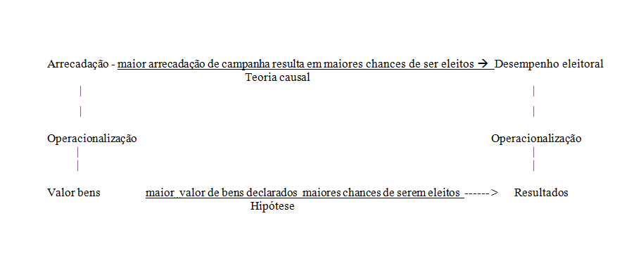

2.3 Descrição dos dados

2.3.1 Dimensão temporal e espacial

```
A dimensão temporal dos dados será a eleição federal ocorrida no ano de 2018, e a dimensão espacial serão os candidatos ao cargo de deputados federais.
```

2.3.2 Considerações sobre a amostra

```
Para esse trabalho será utilizado toda a população (8588 casos) que diz respeito aos candidatos ao cargo de deputados federais nas eleições de 2018.
```

```r
if(!require("devtools"))install.packages("devtools")
library(devtools)

install.packages("dplyr")
library(dplyr)
devtools::install_github("silvadenisson/electionsBR")
```

```
## utf8   (1.2.1 -> 1.2.2) [CRAN]
## tibble (3.1.2 -> 3.1.3) [CRAN]
## readr  (2.0.0 -> 2.0.1) [CRAN]
```

```
## Installing 3 packages: utf8, tibble, readr
```

```
##
##   There is a binary version available but the source version is later:
##       binary source needs_compilation
## readr  2.0.0  2.0.1              TRUE
##
##   Binaries will be installed
```

```
##
##  C:\Users\havai\AppData\Local\Temp\Rtmp2lA4s4\downloaded_packages
```

[output not shown]

[output not shown]

```r
install.packages("electionsBR")
library(electionsBR)
candidatos_2018 <- candidate_fed(2018)
```

```
## Processing the data...
```

```
## Done.
```

```r
glimpse(candidatos_2018)
```

```
## Rows: 29,148
## Columns: 63
## $ DT_GERACAO                    <chr> "08/08/2021", "08/08/2021", "08/08/2021"~
## $ HH_GERACAO                    <time> 11:00:47, 11:00:47, 11:00:47, 11:00:47,~
## $ ANO_ELEICAO                   <dbl> 2018, 2018, 2018, 2018, 2018, 2018, 2018~
## $ CD_TIPO_ELEICAO               <dbl> 2, 2, 2, 2, 2, 2, 2, 2, 2, 2, 2, 2, 2, 2~
## $ NM_TIPO_ELEICAO               <chr> "ELEIÇÃO ORDINÁRIA", "ELEIÇÃO ORDINÁRIA"~
## $ NR_TURNO                      <dbl> 1, 1, 1, 1, 1, 1, 1, 1, 1, 1, 1, 1, 1, 1~
## $ CD_ELEICAO                    <dbl> 297, 297, 297, 297, 297, 297, 297, 297, ~
## $ DS_ELEICAO                    <chr> "Eleições Gerais Estaduais 2018", "Eleiç~
## $ DT_ELEICAO                    <chr> "07/10/2018", "07/10/2018", "07/10/2018"~
## $ TP_ABRANGENCIA                <chr> "ESTADUAL", "ESTADUAL", "ESTADUAL", "EST~
## $ SG_UF                         <chr> "AC", "AC", "AC", "AC", "AC", "AC", "AC"~
## $ SG_UE                         <chr> "AC", "AC", "AC", "AC", "AC", "AC", "AC"~
## $ NM_UE                         <chr> "ACRE", "ACRE", "ACRE", "ACRE", "ACRE", ~
```

[output cut: 50 more lines]

```r
colnames(candidatos_2018)
```

```
##  [1] "DT_GERACAO"                    "HH_GERACAO"
##  [3] "ANO_ELEICAO"                   "CD_TIPO_ELEICAO"
##  [5] "NM_TIPO_ELEICAO"               "NR_TURNO"
##  [7] "CD_ELEICAO"                    "DS_ELEICAO"
##  [9] "DT_ELEICAO"                    "TP_ABRANGENCIA"
## [11] "SG_UF"                         "SG_UE"
## [13] "NM_UE"                         "CD_CARGO"
## [15] "DS_CARGO"                      "SQ_CANDIDATO"
## [17] "NR_CANDIDATO"                  "NM_CANDIDATO"
## [19] "NM_URNA_CANDIDATO"             "NM_SOCIAL_CANDIDATO"
## [21] "NR_CPF_CANDIDATO"              "NM_EMAIL"
## [23] "CD_SITUACAO_CANDIDATURA"       "DS_SITUACAO_CANDIDATURA"
## [25] "CD_DETALHE_SITUACAO_CAND"      "DS_DETALHE_SITUACAO_CAND"
## [27] "TP_AGREMIACAO"                 "NR_PARTIDO"
## [29] "SG_PARTIDO"                    "NM_PARTIDO"
```

[output cut: 17 more lines]

```r
install.packages("tidyverse")
library(tidyverse)
library(readxl)

setwd ("C:\\Users\\havai\\Desktop\\ANÁLISE DE DADOS")

banco_renda <- read.csv("bem_candidato_2018_BRASIL.csv", sep = ";", dec = ",", quote = '"')

banco_renda <- banco_renda %>% group_by(SQ_CANDIDATO, SG_UF)

banco_renda <- banco_renda %>% summarise(valor_bens = sum(VR_BEM_CANDIDATO))
banco_renda <- banco_renda %>% ungroup()

install.packages("plyr")
library(plyr)
colnames(candidatos_2018)
```

```
##  [1] "DT_GERACAO"                    "HH_GERACAO"
##  [3] "ANO_ELEICAO"                   "CD_TIPO_ELEICAO"
##  [5] "NM_TIPO_ELEICAO"               "NR_TURNO"
##  [7] "CD_ELEICAO"                    "DS_ELEICAO"
##  [9] "DT_ELEICAO"                    "TP_ABRANGENCIA"
## [11] "SG_UF"                         "SG_UE"
## [13] "NM_UE"                         "CD_CARGO"
## [15] "DS_CARGO"                      "SQ_CANDIDATO"
## [17] "NR_CANDIDATO"                  "NM_CANDIDATO"
## [19] "NM_URNA_CANDIDATO"             "NM_SOCIAL_CANDIDATO"
## [21] "NR_CPF_CANDIDATO"              "NM_EMAIL"
## [23] "CD_SITUACAO_CANDIDATURA"       "DS_SITUACAO_CANDIDATURA"
## [25] "CD_DETALHE_SITUACAO_CAND"      "DS_DETALHE_SITUACAO_CAND"
## [27] "TP_AGREMIACAO"                 "NR_PARTIDO"
## [29] "SG_PARTIDO"                    "NM_PARTIDO"
```

[output cut: 17 more lines]

```r
colnames(candidatos_2018)[16] <- "SQ_CANDIDATO"

banco_tse <- join(candidatos_2018, banco_renda, by = "SQ_CANDIDATO")

View(banco_tse)

install.packages("memisc")
library(memisc)
colnames(banco_tse)
```

```
##  [1] "DT_GERACAO"                    "HH_GERACAO"
##  [3] "ANO_ELEICAO"                   "CD_TIPO_ELEICAO"
##  [5] "NM_TIPO_ELEICAO"               "NR_TURNO"
##  [7] "CD_ELEICAO"                    "DS_ELEICAO"
##  [9] "DT_ELEICAO"                    "TP_ABRANGENCIA"
## [11] "SG_UF"                         "SG_UE"
## [13] "NM_UE"                         "CD_CARGO"
## [15] "DS_CARGO"                      "SQ_CANDIDATO"
## [17] "NR_CANDIDATO"                  "NM_CANDIDATO"
## [19] "NM_URNA_CANDIDATO"             "NM_SOCIAL_CANDIDATO"
## [21] "NR_CPF_CANDIDATO"              "NM_EMAIL"
## [23] "CD_SITUACAO_CANDIDATURA"       "DS_SITUACAO_CANDIDATURA"
## [25] "CD_DETALHE_SITUACAO_CAND"      "DS_DETALHE_SITUACAO_CAND"
## [27] "TP_AGREMIACAO"                 "NR_PARTIDO"
## [29] "SG_PARTIDO"                    "NM_PARTIDO"
```

[output cut: 18 more lines]

```r
banco_tse$DES_SIT_TOT_TURNO
```

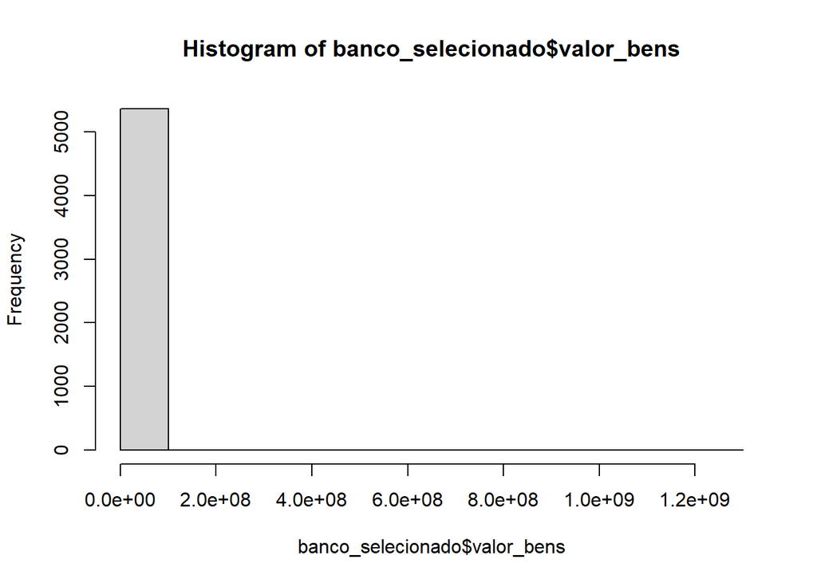

```r
banco_tse_dep <- subset(banco_tse, c(banco_tse$DS_CARGO == "DEPUTADO FEDERAL"))

write.csv(banco_tse, "banco_tse_COMPLETO.csv", row.names = FALSE)

write.csv(banco_tse_dep, "banco_tse_DEPUTADOS.csv", row.names = FALSE)

view(banco_tse_dep)

banco_selecionado <- banco_tse_dep %>%
  dplyr::select(NM_CANDIDATO,SQ_CANDIDATO,SG_PARTIDO,SG_UF_NASCIMENTO,CD_GENERO,DS_GENERO,              DS_GRAU_INSTRUCAO,DS_ESTADO_CIVIL,DS_COR_RACA,DS_OCUPACAO,CD_SIT_TOT_TURNO,
                DS_SIT_TOT_TURNO,ST_REELEICAO,valor_bens)

hist(banco_selecionado$valor_bens)
```

```r
summary(banco_selecionado$valor_bens)
```

```
##      Min.   1st Qu.    Median      Mean   3rd Qu.      Max.      NA's
## 0.000e+00 7.193e+04 2.721e+05 1.741e+06 7.800e+05 1.202e+09      3222
```

```r
library(dplyr)

library(ggthemes)

summary(banco_selecionado$CD_SIT_TOT_TURNO)
```

```
##    Min. 1st Qu.  Median    Mean 3rd Qu.    Max.
##  -1.000   4.000   5.000   4.136   5.000   5.000
```

```r
banco_selecionado$Resultado <- recode(banco_selecionado$CD_SIT_TOT_TURNO,
                               1 <- c("1", "2", "3"),
                               0 <- c("4", "5"))

banco_selecionado$Gênero <- recode(banco_selecionado$CD_GENERO,
                               1 <- c("4"),
                               0 <- c("2"))

banco_selecionado$Raça <- recode(banco_selecionado$DS_COR_RACA,
                               1 <- c("BRANCA"),
                               0 <- c("PARDA", "INDÍGENA", "PRETA", "AMARELA"))

banco_selecionado$Casado <- recode(banco_selecionado$DS_ESTADO_CIVIL,
                                   1 <- c("CASADO(A)"),
                                   0 <- c("DIVORCIADO(A)", "SOLTEIRO(A)"))
```

2.3.3 Que tipo de variável você usa?

Resultado (variável dependente) – variável categórica binária (1- eleito e 0 – não eleito). O gráfico indicado para observação desse tipo de variável é o gráfico de barras.No gráfico abaixo, vemos que do lado esquerdo encontram-se os candidtos que não foram eleitos e do lado direito, os candidatos eleitos para a 56ª legislatura.

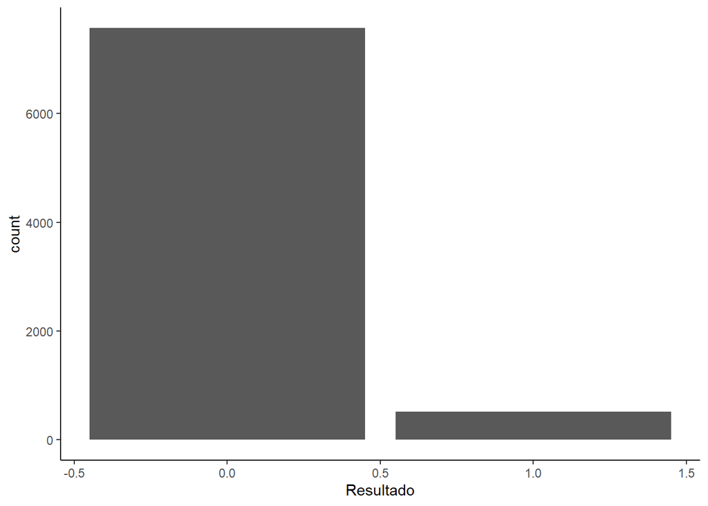

```r
ggplot(banco_selecionado, aes(x=Resultado))+
  geom_bar()+
  theme_classic()
```

Gênero (variável independente) – variável categórica binária (1 - Mulher e 0- Homem). Aqui também o gráfico indicado para uma melhor observação da variável categórica gênero é o gráfico de barras. Do lado esquerdo do gráfico vimos os candidatos homens e do lado esquerdo as candidatas mulheres. Já podemos notar uma grande disparidade de gênero no número das candidaturas.

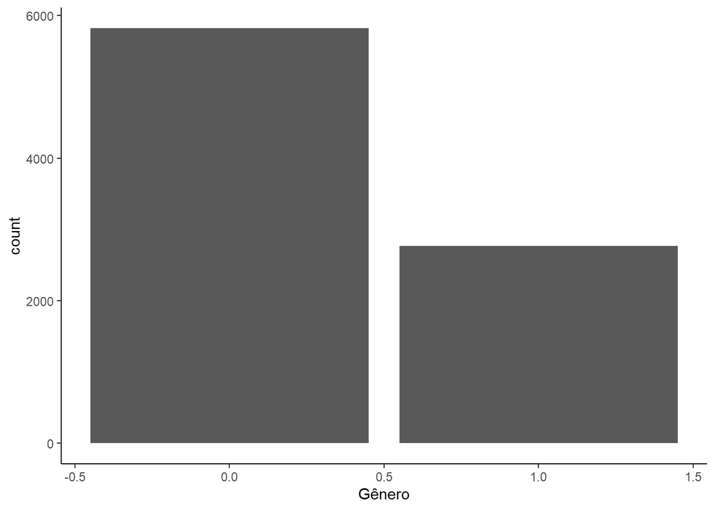

```r
ggplot(banco_selecionado, aes(x=Gênero))+
  geom_bar()+
  theme_classic()
```

Raça (variável independente) – variável categórica binária (1 - Branco e 0 - Não branco (preta, parda,indígena e amarela)). Nesse caso, o gráfico indicado para uma melhor observação de uma variável categórica é o gráfico de barras. Do lado esquerdo do gráfico temos os candidatos brancos e do lado direito encontram-se os candidatos não brancos.Percebemos também a grande disparidade dos candidatos na categoria raça, pois o número de concorrentes brancos é significativamente maior do que de candidatos não brancos.

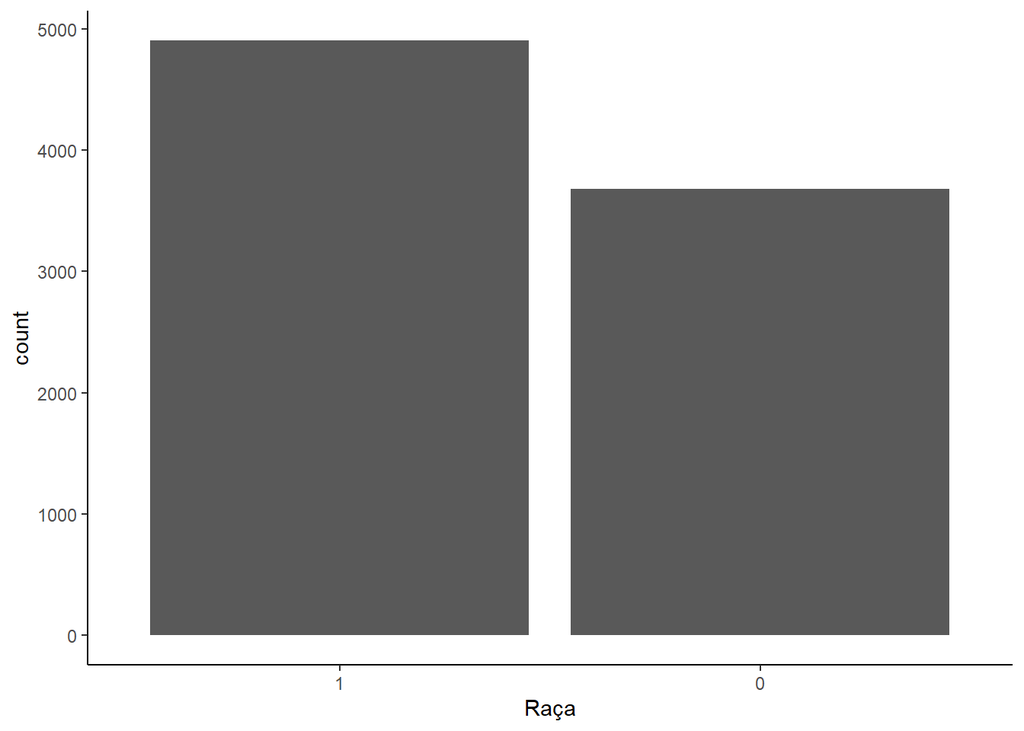

```r
ggplot(banco_selecionado, aes(x=Raça))+
  geom_bar()+
  theme_classic()
```

Casado (variável independente) – variável categórica binária (1- casado e 0 - não casado (solteiro, divorciado, entre outros)). Dado que a variável é categórica, o gráfico utilizado para uma melhor visualização da variável é o gráfico de barras.Na coluna da esquerda temos os candidatos casados, na coluna do centro os não casados e na coluna da direita os não respondentes.

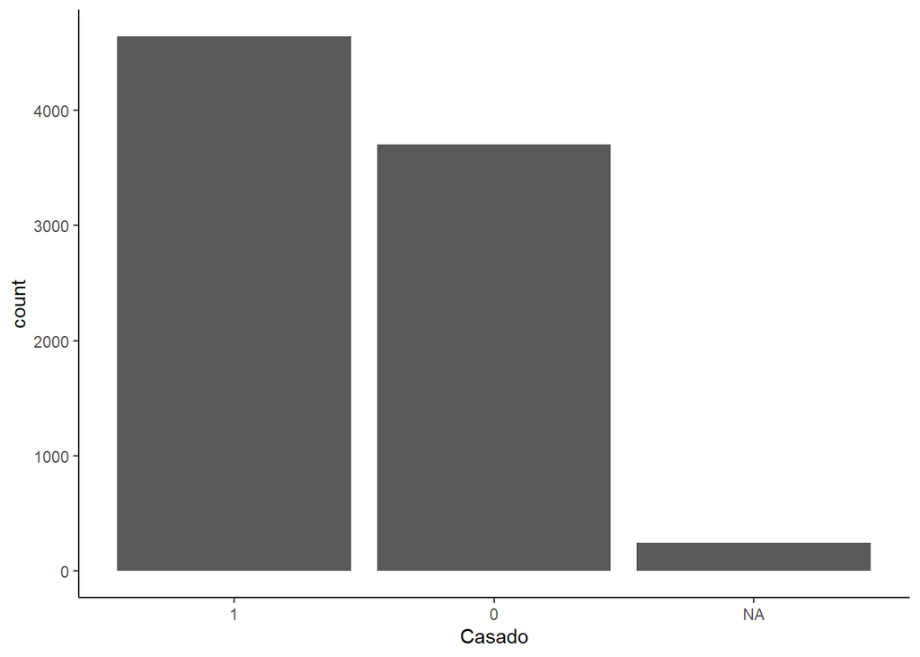

```r
ggplot(banco_selecionado, aes(x=Casado))+
  geom_bar()+
  theme_classic()
```

Valor_bens (variável independente pricipal) – variável contínua. Nesse caso, dado que nossa variável é contínua, existem diversas formas para observarmos os valores graficamente. Temos o histograma, a curva de densidade, o gráfico de pontos e o gráfico boxplot (que será utilizado no comando abaixo). Uma breve interpretação já mostra que teremos diversos casos de outliers.

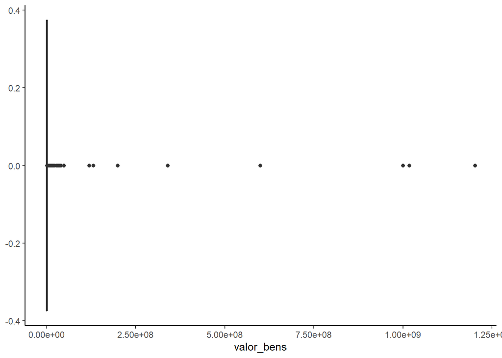

```r
ggplot(banco_selecionado, aes(valor_bens)) +
geom_boxplot()+
  theme_classic()
```

2.3.5 Gráficos e testes adequados para descrever a associação entre as variáveis:

1. Resultado eleitoral (variável categórica binária) quando associada a variável gênero, raça e casado o melhor teste é o Teste Chi-quadrado, pois todas são categóricas binárias. O gráfico nesse caso é o de barra. Quando associada a variável valor_bens (variável contínua) o teste é o test T e o gráfico é o de densidade, boxplot ou violino.
- Teste de associação e gráfico: Resultado x Gênero

  O teste de chi-quadrado realizado para associação entre a variável resultado e a variável gênero (teste abaixo) mostra um p-valor baixo e um alto valor para o x2. Nesse caso, podemos rejeitar a hipótese nula de que as variáveis não estão associadas. Portanto, há associação entre as variáveis.

```r
chisq.test(banco_selecionado$Resultado, banco_selecionado$Gênero)
```

```
##
##  Pearson's Chi-squared test with Yates' continuity correction
##
## data:  banco_selecionado$Resultado and banco_selecionado$Gênero
## X-squared = 69.004, df = 1, p-value < 2.2e-16
```

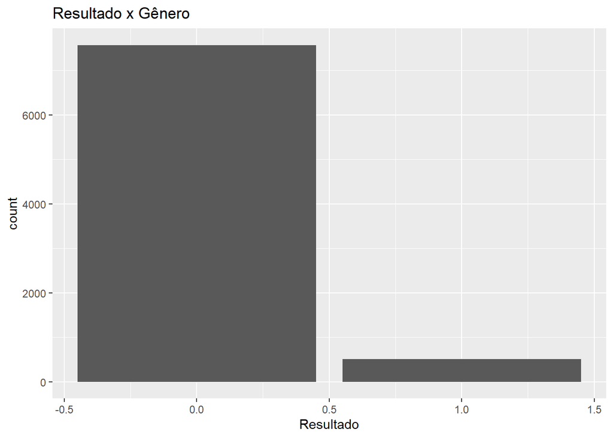

```r
ggplot(banco_selecionado, aes(Resultado, fill=Gênero))+
    geom_bar()+
  labs (title = "Resultado x Gênero")
```

- Teste de associação e gráfico: Resultado x Raça

O teste de chi-quadrado realizado para a associação entre as variáveis resultado e raça (teste abaixo) mostra um p-valor baixo e um alto valor para o x2. Nesse caso, podemos rejeitar a hipótese nula de que as variáveis não estão associadas.Portanto, há associação entre as variáveis.O gráfico na coluna da esquerda nos mostra os candidatos não eleitos e na coluna da direita, os candidatos eleitos, sendo proporcionalmente maior o número de candidatos brancos eleitos (na cor rosa).

```r
chisq.test(banco_selecionado$Resultado, banco_selecionado$Raça)
```

```
##
##  Pearson's Chi-squared test with Yates' continuity correction
##
## data:  banco_selecionado$Resultado and banco_selecionado$Raça
## X-squared = 69.495, df = 1, p-value < 2.2e-16
```

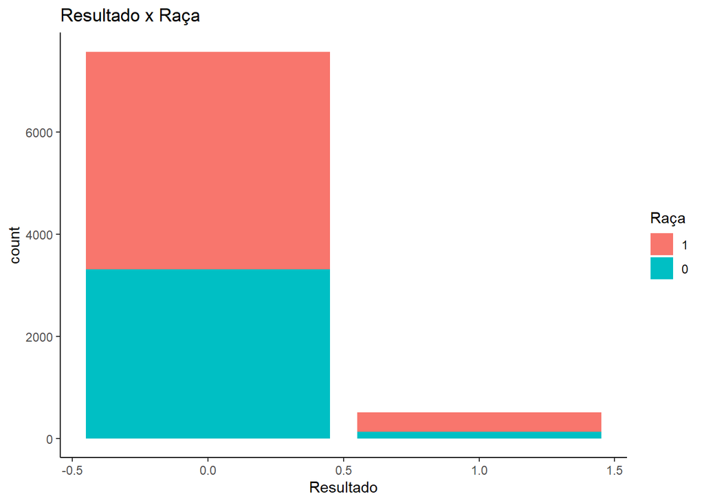

```r
ggplot(banco_selecionado, aes(Resultado, fill= Raça))+
    geom_bar()+
  theme_classic()+
  labs (title = "Resultado x Raça")
```

- Teste de associação e gráfico:Resultado x Casado

O teste de chi-quadrado realizado para medir a associação entre as variáveis resultado e casado (teste abaixo) mostra um p-valor baixo e um alto valor para o x2. Nesse caso, podemos rejeitar a hipótese nula de que as variáveis não estão associadas.Portanto, há associação entre as variáveis.O gráfico mostra que os casados são maioria no número de candidatos e maioria dos eleitos (na coluna da direita).

```r
library(tidyverse)

chisq.test(banco_selecionado$Resultado, banco_selecionado$Casado)
```

```
##
##  Pearson's Chi-squared test with Yates' continuity correction
##
## data:  banco_selecionado$Resultado and banco_selecionado$Casado
## X-squared = 44.51, df = 1, p-value = 2.53e-11
```

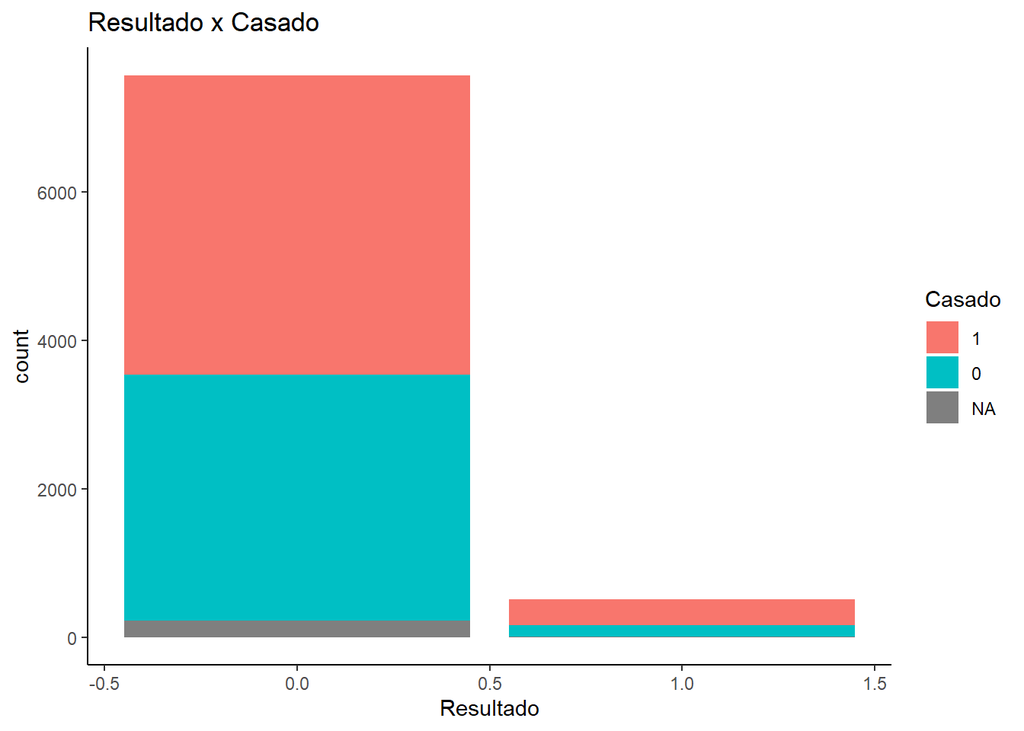

```r
ggplot(banco_selecionado, aes(Resultado, fill= Casado))+
    geom_bar()+
  theme_classic()+
  labs (title = "Resultado x Casado")
```

- Teste e gráfico de associação: Resultado x Log_Bens